# Analyse de devox 2016

by Nathaniel Richand

24 avril 2016

Devoxx France 2016 c’est terminé. Personnellement j’ai trouvé cette mouture vraiment bien. Je me suis amusé à faire cette rapide page pour voir si mon ressenti était partagé, puis pour voir les trends de ce qui a bien marché à Devoxx.

> *N’étant pas propriétaire de la donnée et ne connaissant pas son statut celle-ci n’est pas commitée sur le repo.*

> *A noter : je n’ai réussi qu’à récupérer les notes de 197 slots sur les 220 du programmes.*

# Petit tour sur les soumissions

## Nombre de sujets

Le gros de devoxx c’est toujours les conférences :

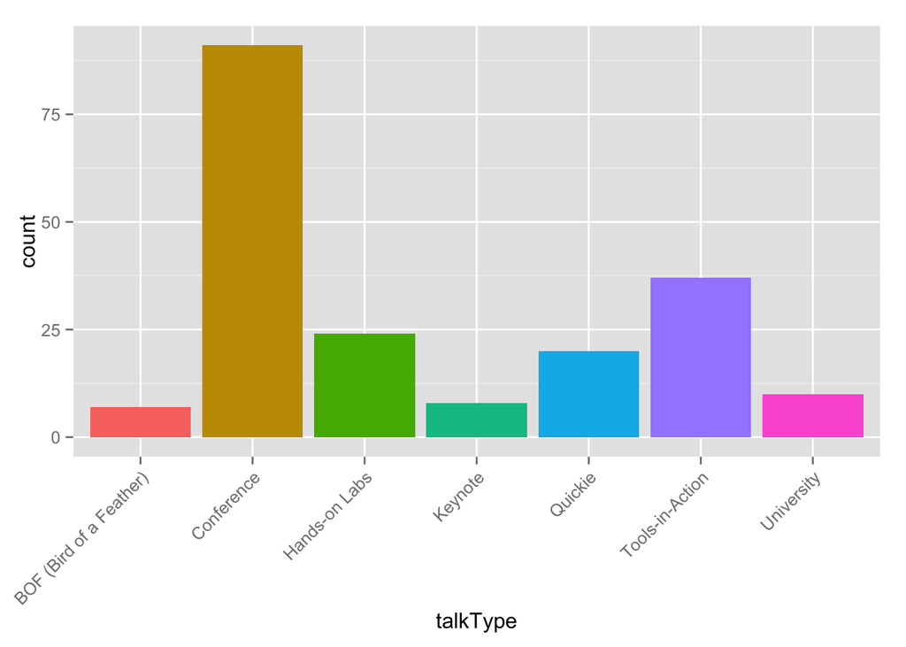

Par contre si on ramène à la durée des confs les hands On sont au niveau des conférences.

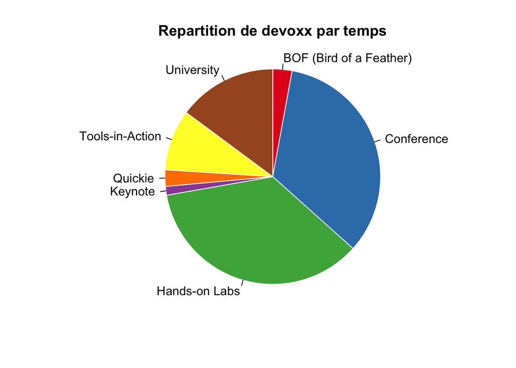

Toujours un peu d’anglais à DevoxxFR, mais pas énormément non plus et surtout sur les conférences :

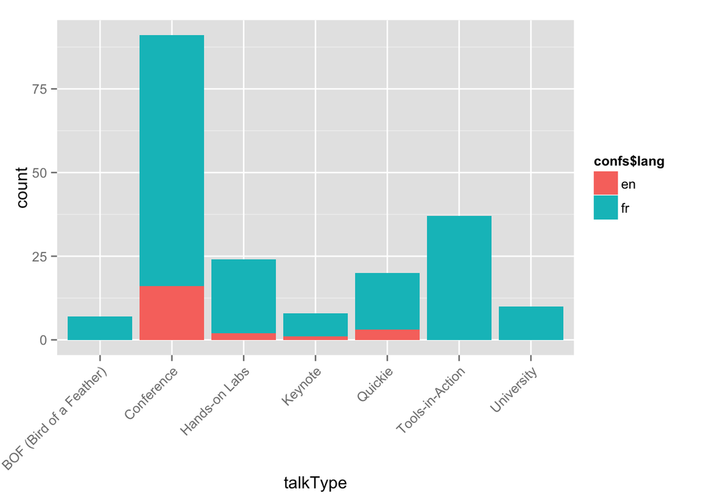

En terme de track, nous avons une track plus représentée que les autres :

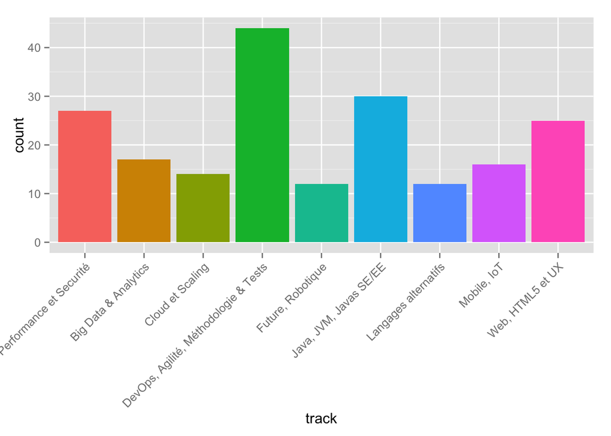

Si on zoome sur les propositions de la track Devops, Agilité, Méthodologie & Tests :

```
##  [1] BOF Jenkins
##  [2] BoF Communautés Software Craftsmanship
##  [3] DDD: et si on reprenait l'histoire par le bon bout ?
##  [4] I'm a CTO bitch! ou Pérégrination d'un CTO
##  [5] How to stop wasting your time and start performing useful code reviews
##  [6] How to defeat feature gluttony?
##  [7] Intégration et déploiement en continu @ Github
##  [8] Containers, VMs, Processes… Isolation, performances, I/O… How all of these technologies work and compare to each other?
##  [9] (Jenkins, Docker) -> { Orchestrons le Continuous Delivery }
## [10] // TODO Implémenter le modèle de l’entreprise [de service] de demain
## [11] // TODO Implémenter le modèle de l’entreprise [de service] de demain
## [12] L'odyssée du Continuous Delivery
## [13] Scaling with Kubernetes, Automatically!  Learn Kubernetes API through writing a visualizer to an autoscaler
## [14] A la découverte du service discovery
## [15] Ce que les stratégies de versioning nous disent des dynamiques d’équipe
```

[output cut: 30 more lines]

*Peut-être mettre la track Devops à part?*

A noter que les sessions en anglais sont réparties sur toutes les tracks :

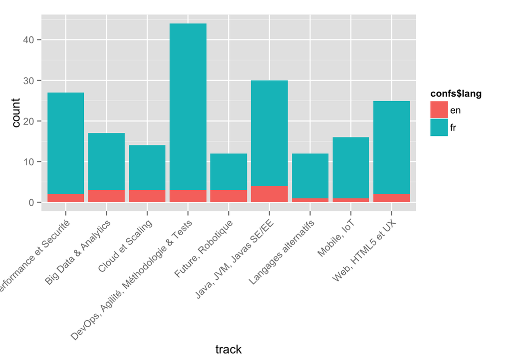

## Analyse des résumés de sessions

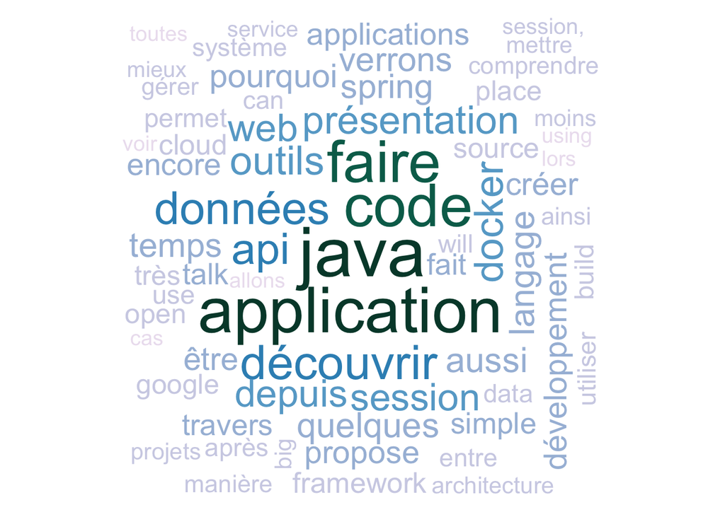

Java est toujours au centre de Devoxx, a noter la grosse cote de Docker cette année…

# Notation des talks

Faisons un tour sur les notes moyennes des sujets

```
##    Min. 1st Qu.  Median    Mean 3rd Qu.    Max.
##   3.000   3.741   4.053   4.037   4.367   4.909
```

En moyenne et le median sont autour de 4. La note max est de 4.9 et la min est à 3 (je me demande si ce n’est pas le service qui filtre les sessions < 3 ?).

### Notation par types de talks

Prêt de la moitié des votes ont été fait sur les conférences :

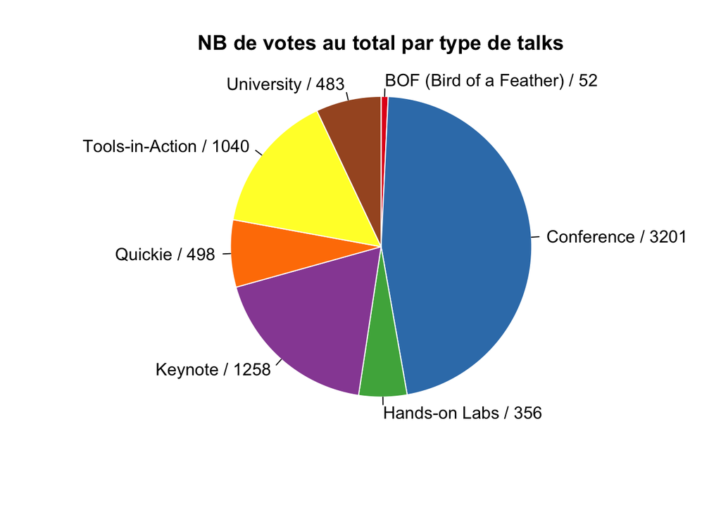

Il y a peu de votes en moyenne pour les BOF (normal car le nombre de participant y est plus faible), par contre les university sont beaucoup votés.

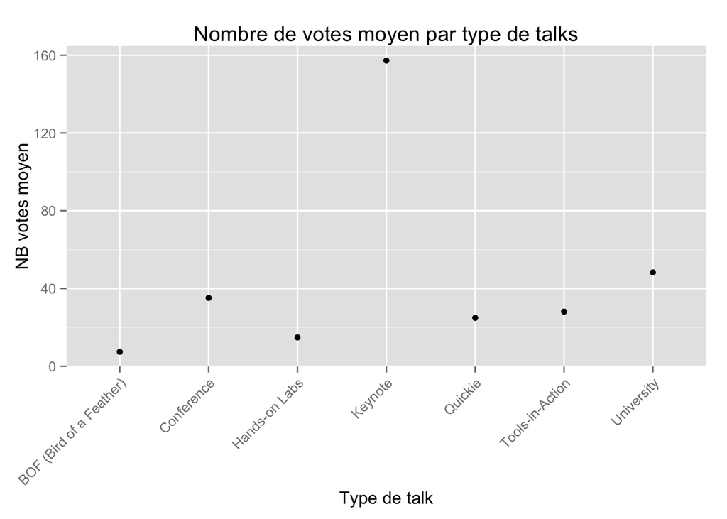

Les BOF & Universités sont plebiscités, les Tools In Action ont moins plu cette année :

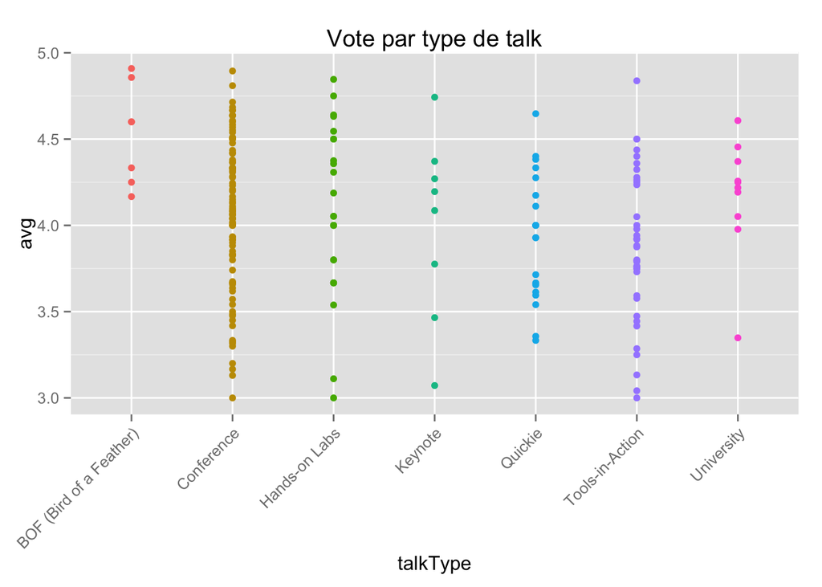

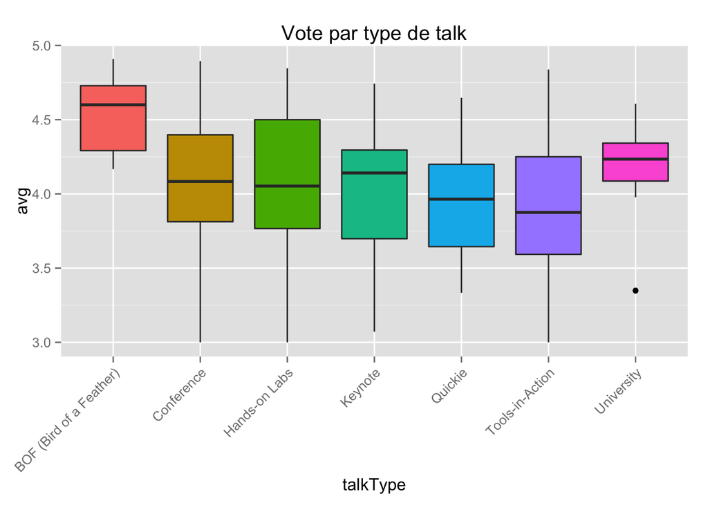

### Notation par tracks

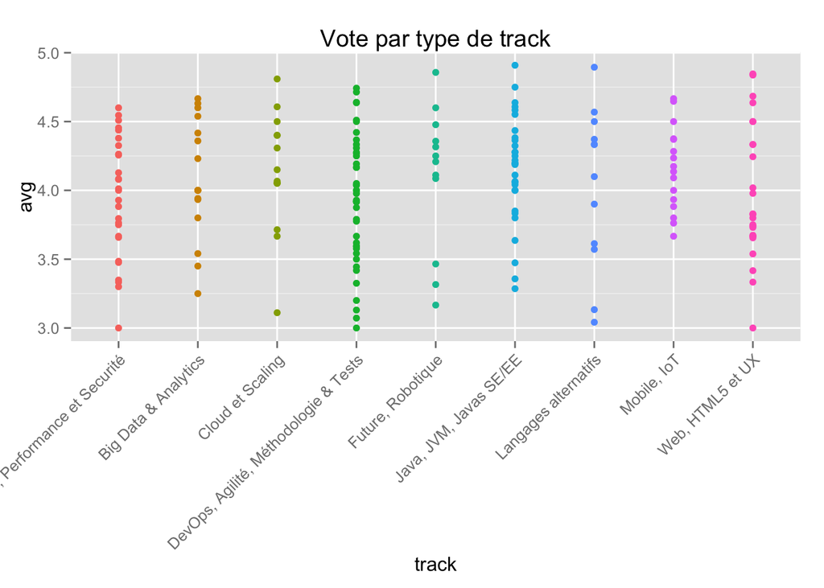

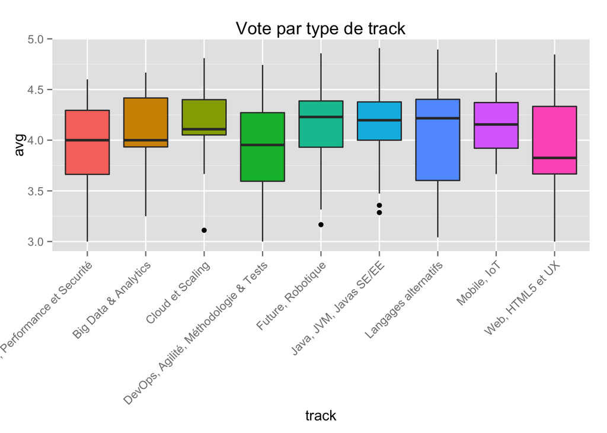

4 tracks sortent du lot : Java/JVM, Future & Robotique, Langages alternatifs, Mobile & IOT. Cependant, les votes de la track langages alternatifs sont plus répartis. A noter aussi que la track Web, HTML5 et UX est un peu moins bien notée.